# Analyse de données sur l’athérosclérose

Hamza QURESHI

# Introduction

Dans ce projet, l’objectif est d’identifier les facteurs de risque associés à l’athérosclérose, une pathologie vasculaire caractérisée par un épaississement des parois artérielles. Ce phénomène est un facteur principal dans le développement des maladies cardiovasculaires, qui représentent une des premières causes de décès dans le monde. À travers l’analyse des données disponibles, nous cherchons à déterminer les variables (âge, sexe, tabac, activité physique, alcool, etc.) qui influencent cette mesure vasculaire.

# Préparation des données

Certaines variables numériques et qualitatives doivent être correctement formatées pour l’analyse. Cela inclut le remplacement des valeurs manquantes et la transformation des variables qualitatives en facteurs.

```r
intima_data$paqan[is.na(intima_data$paqan)] <- 0
```

Les variables AGE, taille, poids, paqan, et mesure sont quantitatives continues et prêtes à être utilisées dans l’analyse. Toutefois, les variables SEXE, tabac, SPORT, et alcool sont de type qualitatif. Elles doivent être converties en facteurs afin de les traiter correctement dans les analyses statistiques.

```r
intima_data$SEXE <- factor(intima_data$SEXE)
intima_data$tabac <- factor(intima_data$tabac)
intima_data$SPORT <- factor(intima_data$SPORT)
intima_data$alcool <- factor(intima_data$alcool)
```

# Statistiques descriptives

Avant d’effectuer des analyses plus complexes, il est essentiel de comprendre les principales caractéristiques de l’échantillon à travers des statistiques descriptives. Cela permet de vérifier la présence de valeurs aberrantes, d’identifier des tendances globales et d’évaluer la qualité des données.

```r
(dfSummary(intima_data))
```

[output not shown]

Ce rapport descriptif nous fournit des informations détaillées sur les moyennes, médianes, et les distributions des variables. Il permet également de détecter la présence de valeurs manquantes ou incohérentes, ce qui est important avant de commencer l’analyse statistique.

# Modèle linéaire

Nous allons maintenant construire un modèle de régression linéaire multiple pour expliquer la variation de l’intima-média en fonction de plusieurs facteurs de risque (âge, sexe, tabac, alcool, etc.). Un premier modèle complet sera estimé, puis simplifié par sélection de variables.

```r
mod1 = lm(mesure ~ SEXE + AGE + taille + poids + tabac + paqan + SPORT + alcool, data = intima_data)

mod2 <- step(mod1)

anova(mod1, mod2)
```

[output not shown]

Les résultats du modèle final (modèle 2) sont présentés ci-dessous. Les coefficients de régression indiquent l’impact de chaque variable sur l’épaisseur de l’intima-média. Les p-values inférieures à 0,05 suggèrent une influence significative des variables sur la mesure de l’intima-média.

```r
summary(mod2)$coefficients
```

```
##                Estimate   Std. Error  t value     Pr(>|t|)
## (Intercept) 0.246151254 0.0424069574 5.804502 6.673083e-08
## AGE         0.004377577 0.0005965905 7.337659 4.426429e-11
## poids       0.001643159 0.0004958289 3.313963 1.255915e-03
```

L’analyse des p-values montre que l’âge et le poids ont des p-values très faibles, ce qui indique qu’ils ont un impact significatif sur l’intima-média. En revanche, d’autres variables comme le tabac et l’alcool semblent n’avoir aucun effet statistiquement significatif.

# Vérifier l’absence de multicolinéarité

Nous devons vérifier qu’il n’y a pas de multicolinéarité entre les variables explicatives, ce qui pourrait affecter la stabilité des coefficients. Nous utilisons pour cela des graphiques de corrélation et les indices VIF (Variance Inflation Factor).

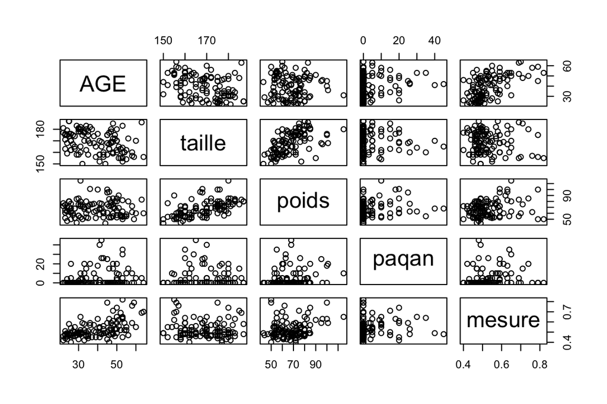

```r
pairs(intima_data[, c(2:4, 6, 8)])
```

Afin de confirmer ces observations visuelles, nous calculons ensuite la matrice de corrélation entre les variables quantitatives continues. Cette étape permet de quantifier la force et le sens des relations linéaires identifiées dans le graphique précédent.

```r
cor(intima_data[, c(2:4, 6, 8)])
```

```
##                AGE      taille       poids      paqan      mesure
## AGE     1.00000000 -0.34641559 -0.04446022 0.19442269  0.55236686
## taille -0.34641559  1.00000000  0.56887235 0.00334401 -0.06865902
## poids  -0.04446022  0.56887235  1.00000000 0.14458608  0.22952003
## paqan   0.19442269  0.00334401  0.14458608 1.00000000  0.15287691
## mesure  0.55236686 -0.06865902  0.22952003 0.15287691  1.00000000
```

Nous allons à présent vérifier l’absence de multicolinéarité entre les variables explicatives à l’aide du facteur d’inflation de la variance (VIF), afin de s’assurer que le modèle reste stable et interprétable.

```
##      AGE    poids
## 1.001981 1.001981
```

Les indices de VIF pour les variables explicatives sont inférieurs à 5, ce qui indique qu’il n’y a pas de multicolinéarité problématique dans notre modèle.

# Vérification des résidus

Une étape essentielle dans l’analyse des modèles de régression est la vérification des résidus. Cette analyse nous permet de confirmer que les hypothèses du modèle linéaire (normalité des résidus, homogénéité des variances, etc.) sont respectées.

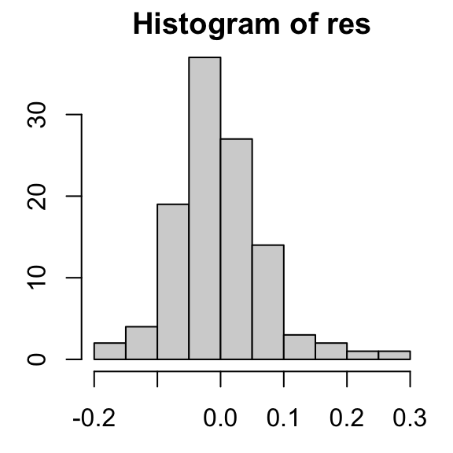

L’histogramme montre que les résidus sont bien distribués autour de zéro, suggérant que les erreurs suivent une loi normale.

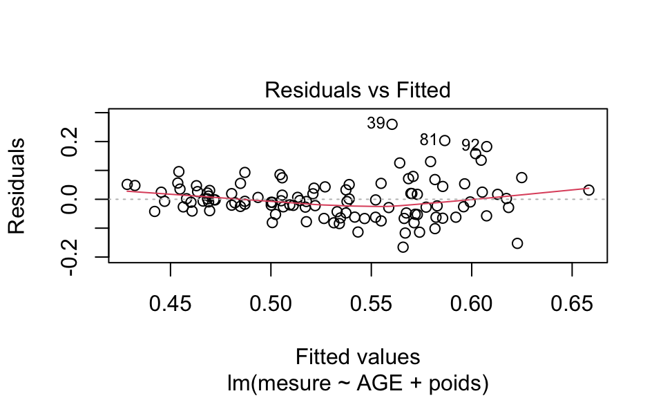

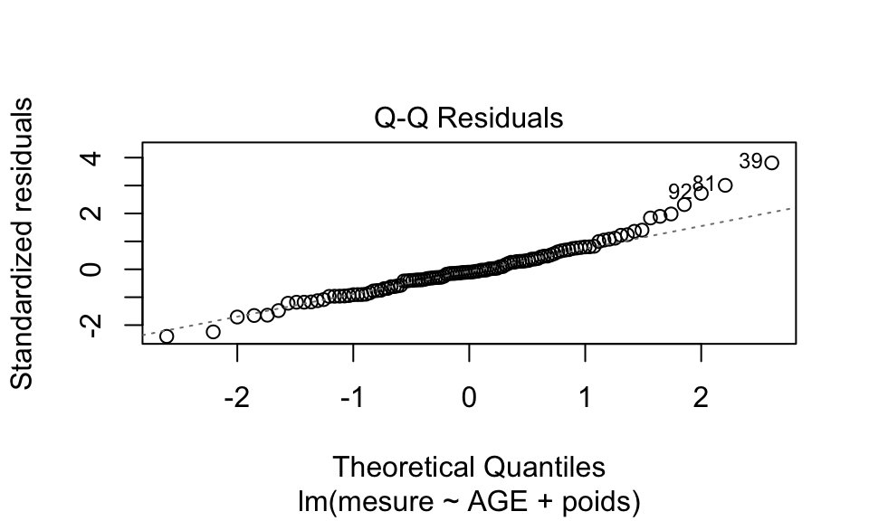

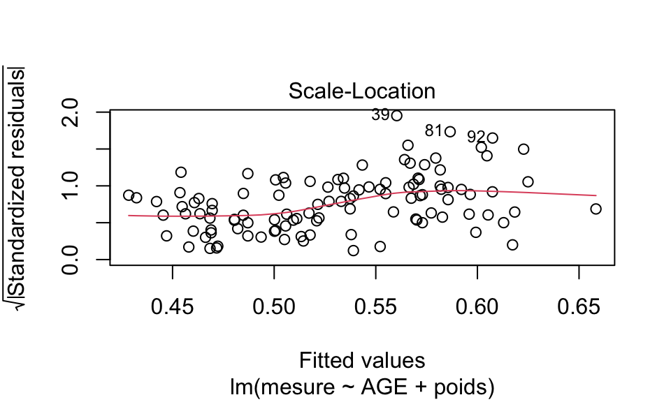

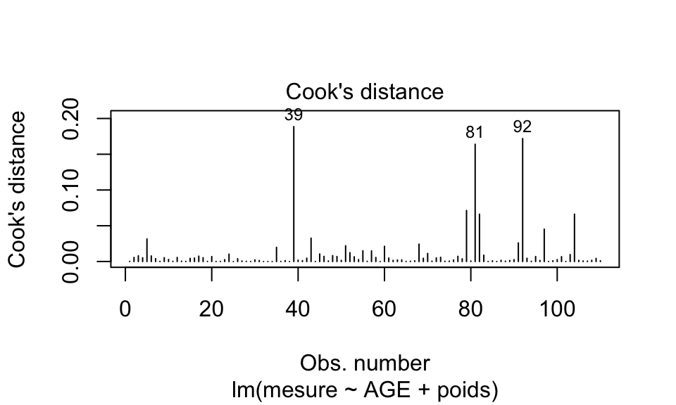

Analyse du diagnostic des résidus :

```
##   dfb.1_  dfb.AGE dfb.pods    dffit    cov.r   cook.d      hat
##    FALSE    FALSE    FALSE     TRUE     TRUE    FALSE    FALSE
```

# Conclusion